# Personal Loan Campaign

### Looking at potential data entry errors

```python
#Lets look at Experience closely, there are negative numbers here which seem odd
data['Experience'].value_counts()
```

```
 32    154
 20    148
 9     147
 5     146
 23    144
 35    143
 25    142
 28    138
 18    137
 19    135
 26    134
 24    131
 3     129
 16    127
 14    127
```

[output cut: 33 more lines]

```python
#Printing the rows where Experience is -1
data[data['Experience'] == -1]
```

|  | Age | Experience | Income | ZIPCode | Family | CCAvg | Education | Mortgage | Personal_Loan | Securities_Account | CD_Account | Online | CreditCard |
| --- | --- | --- | --- | --- | --- | --- | --- | --- | --- | --- | --- | --- | --- |
| 89 | 25 | -1 | 113 | 94 | 4 | 2.30 | 3 | 0 | 0 | 0 | 0 | 0 | 1 |
| 226 | 24 | -1 | 39 | 94 | 2 | 1.70 | 2 | 0 | 0 | 0 | 0 | 0 | 0 |
| 524 | 24 | -1 | 75 | 93 | 4 | 0.20 | 1 | 0 | 0 | 0 | 0 | 1 | 0 |
| 536 | 25 | -1 | 43 | 92 | 3 | 2.40 | 2 | 176 | 0 | 0 | 0 | 1 | 0 |
| 540 | 25 | -1 | 109 | 94 | 4 | 2.30 | 3 | 314 | 0 | 0 | 0 | 1 | 0 |
| 576 | 25 | -1 | 48 | 92 | 3 | 0.30 | 3 | 0 | 0 | 0 | 0 | 0 | 1 |
| 583 | 24 | -1 | 38 | 95 | 2 | 1.70 | 2 | 0 | 0 | 0 | 0 | 1 | 0 |
| 649 | 25 | -1 | 82 | 92 | 4 | 2.10 | 3 | 0 | 0 | 0 | 0 | 1 | 0 |
| 670 | 23 | -1 | 61 | 92 | 4 | 2.60 | 1 | 239 | 0 | 0 | 0 | 1 | 0 |
| 686 | 24 | -1 | 38 | 92 | 4 | 0.60 | 2 | 0 | 0 | 0 | 0 | 1 | 0 |
| 909 | 23 | -1 | 149 | 91 | 1 | 6.33 | 1 | 305 | 0 | 0 | 0 | 0 | 1 |
| 1173 | 24 | -1 | 35 | 94 | 2 | 1.70 | 2 | 0 | 0 | 0 | 0 | 0 | 0 |
| 1428 | 25 | -1 | 21 | 94 | 4 | 0.40 | 1 | 90 | 0 | 0 | 0 | 1 | 0 |
| 1522 | 25 | -1 | 101 | 94 | 4 | 2.30 | 3 | 256 | 0 | 0 | 0 | 0 | 1 |
| 1905 | 25 | -1 | 112 | 92 | 2 | 2.00 | 1 | 241 | 0 | 0 | 0 | 1 | 0 |
| 2102 | 25 | -1 | 81 | 92 | 2 | 1.60 | 3 | 0 | 0 | 0 | 0 | 1 | 1 |
| 2430 | 23 | -1 | 73 | 92 | 4 | 2.60 | 1 | 0 | 0 | 0 | 0 | 1 | 0 |
| 2545 | 25 | -1 | 39 | 94 | 3 | 2.40 | 2 | 0 | 0 | 0 | 0 | 1 | 0 |
| 2848 | 24 | -1 | 78 | 94 | 2 | 1.80 | 2 | 0 | 0 | 0 | 0 | 0 | 0 |
| 2980 | 25 | -1 | 53 | 94 | 3 | 2.40 | 2 | 0 | 0 | 0 | 0 | 0 | 0 |
| 3076 | 29 | -1 | 62 | 92 | 2 | 1.75 | 3 | 0 | 0 | 0 | 0 | 0 | 1 |
| 3157 | 23 | -1 | 13 | 94 | 4 | 1.00 | 1 | 84 | 0 | 0 | 0 | 1 | 0 |
| 3279 | 26 | -1 | 44 | 94 | 1 | 2.00 | 2 | 0 | 0 | 0 | 0 | 0 | 0 |
| 3284 | 25 | -1 | 101 | 95 | 4 | 2.10 | 3 | 0 | 0 | 0 | 0 | 0 | 1 |
| 3292 | 25 | -1 | 13 | 95 | 4 | 0.40 | 1 | 0 | 0 | 1 | 0 | 0 | 0 |
| 3394 | 25 | -1 | 113 | 90 | 4 | 2.10 | 3 | 0 | 0 | 0 | 0 | 1 | 0 |
| 3425 | 23 | -1 | 12 | 91 | 4 | 1.00 | 1 | 90 | 0 | 0 | 0 | 1 | 0 |
| 3824 | 23 | -1 | 12 | 95 | 4 | 1.00 | 1 | 0 | 0 | 1 | 0 | 0 | 1 |
| 3946 | 25 | -1 | 40 | 93 | 3 | 2.40 | 2 | 0 | 0 | 0 | 0 | 1 | 0 |
| 4015 | 25 | -1 | 139 | 93 | 2 | 2.00 | 1 | 0 | 0 | 0 | 0 | 0 | 1 |
| 4088 | 29 | -1 | 71 | 94 | 2 | 1.75 | 3 | 0 | 0 | 0 | 0 | 0 | 0 |
| 4582 | 25 | -1 | 69 | 92 | 3 | 0.30 | 3 | 0 | 0 | 0 | 0 | 1 | 0 |
| 4957 | 29 | -1 | 50 | 95 | 2 | 1.75 | 3 | 0 | 0 | 0 | 0 | 0 | 1 |

There are 33 customers with Experience as -1, they are in their 20s for age. None of them accepted the Personal_Loan before. None of them have a CD_Account. And only 2 have a Securities_Account

```python
#Printing the rows where Experience is -2
data[data['Experience'] == -2]
```

|  | Age | Experience | Income | ZIPCode | Family | CCAvg | Education | Mortgage | Personal_Loan | Securities_Account | CD_Account | Online | CreditCard |
| --- | --- | --- | --- | --- | --- | --- | --- | --- | --- | --- | --- | --- | --- |
| 315 | 24 | -2 | 51 | 90 | 3 | 0.30 | 3 | 0 | 0 | 0 | 0 | 1 | 0 |
| 451 | 28 | -2 | 48 | 94 | 2 | 1.75 | 3 | 89 | 0 | 0 | 0 | 1 | 0 |
| 597 | 24 | -2 | 125 | 92 | 2 | 7.20 | 1 | 0 | 0 | 1 | 0 | 0 | 1 |
| 793 | 24 | -2 | 150 | 94 | 2 | 2.00 | 1 | 0 | 0 | 0 | 0 | 1 | 0 |
| 889 | 24 | -2 | 82 | 91 | 2 | 1.60 | 3 | 0 | 0 | 0 | 0 | 1 | 1 |
| 2466 | 24 | -2 | 80 | 94 | 2 | 1.60 | 3 | 0 | 0 | 0 | 0 | 1 | 0 |
| 2717 | 23 | -2 | 45 | 95 | 4 | 0.60 | 2 | 0 | 0 | 0 | 0 | 1 | 1 |
| 2876 | 24 | -2 | 80 | 91 | 2 | 1.60 | 3 | 238 | 0 | 0 | 0 | 0 | 0 |
| 2962 | 23 | -2 | 81 | 91 | 2 | 1.80 | 2 | 0 | 0 | 0 | 0 | 0 | 0 |
| 3130 | 23 | -2 | 82 | 92 | 2 | 1.80 | 2 | 0 | 0 | 1 | 0 | 0 | 1 |
| 3796 | 24 | -2 | 50 | 94 | 3 | 2.40 | 2 | 0 | 0 | 1 | 0 | 0 | 0 |
| 3887 | 24 | -2 | 118 | 92 | 2 | 7.20 | 1 | 0 | 0 | 1 | 0 | 1 | 0 |
| 4116 | 24 | -2 | 135 | 90 | 2 | 7.20 | 1 | 0 | 0 | 0 | 0 | 1 | 0 |
| 4411 | 23 | -2 | 75 | 90 | 2 | 1.80 | 2 | 0 | 0 | 0 | 0 | 1 | 1 |
| 4481 | 25 | -2 | 35 | 95 | 4 | 1.00 | 3 | 0 | 0 | 0 | 0 | 1 | 0 |

```python
#Printing the rows where Experience is -3
data[data['Experience'] == -3]
```

|  | Age | Experience | Income | ZIPCode | Family | CCAvg | Education | Mortgage | Personal_Loan | Securities_Account | CD_Account | Online | CreditCard |
| --- | --- | --- | --- | --- | --- | --- | --- | --- | --- | --- | --- | --- | --- |
| 2618 | 23 | -3 | 55 | 92 | 3 | 2.4 | 2 | 145 | 0 | 0 | 0 | 1 | 0 |
| 3626 | 24 | -3 | 28 | 90 | 4 | 1.0 | 3 | 0 | 0 | 0 | 0 | 0 | 0 |
| 4285 | 23 | -3 | 149 | 93 | 2 | 7.2 | 1 | 0 | 0 | 0 | 0 | 1 | 0 |
| 4514 | 24 | -3 | 41 | 91 | 4 | 1.0 | 3 | 0 | 0 | 0 | 0 | 1 | 0 |

There are 4 customers with Experience as -3, they are also in their 20s for age. None of them accepted the Personal_Loan before. None of them have a CD_Account or Securities_Account

Observation: All the rows that have negative experience have the age in the 20s. The Income, Family and Education seem to spread evenly for these customers. Also none of them have taken a personal loan. From this analysis. it looks like the negative values are a data entry error. We can impute the Experience for these rows by removing the negative sign and keeping the number, in other words taking the absolute value.

```python
# Replace the Experience of negative values with absolute values of the same number
data['Experience'].replace(-1,  1, inplace=True)
data['Experience'].replace(-2,  2, inplace=True)
data['Experience'].replace(-3,  3, inplace=True)
```

```python
data['Experience'].value_counts()
```

```
32    154
20    148
9     147
5     146
23    144
35    143
25    142
28    138
18    137
19    135
26    134
3     133
24    131
16    127
14    127
```

[output cut: 30 more lines]

Observation:There are no negative vlaues now. Also the value_counts for 1 increased by 33 to 107. The value_counts for 2 increased by 15 to 100. Lastly the value_counts for 3 increased by 4 to 133

## Univariate Analysis

### Basic summary statistics and consequences

```python
# function to plot a boxplot and a histogram along the same scale.


def histogram_boxplot(data, feature, figsize=(12, 7), kde=False, bins=None):
    """
    Boxplot and histogram combined

    data: dataframe
    feature: dataframe column
    figsize: size of figure (default (12,7))
    kde: whether to the show density curve (default False)
    bins: number of bins for histogram (default None)
    """
    f2, (ax_box2, ax_hist2) = plt.subplots(
        nrows=2,  # Number of rows of the subplot grid= 2
        sharex=True,  # x-axis will be shared among all subplots
        gridspec_kw={"height_ratios": (0.25, 0.75)},
        figsize=figsize,
    )  # creating the 2 subplots
    sns.boxplot(
        data=data, x=feature, ax=ax_box2, showmeans=True, color="violet"
    )  # boxplot will be created and a star will indicate the mean value of the column
    sns.histplot(
        data=data, x=feature, kde=kde, ax=ax_hist2, bins=bins, palette="winter"
    ) if bins else sns.histplot(
        data=data, x=feature, kde=kde, ax=ax_hist2
    )  # For histogram
    ax_hist2.axvline(
        data[feature].mean(), color="green", linestyle="--"
    )  # Add mean to the histogram
    ax_hist2.axvline(
        data[feature].median(), color="black", linestyle="-"
    )  # Add median to the histogram
```

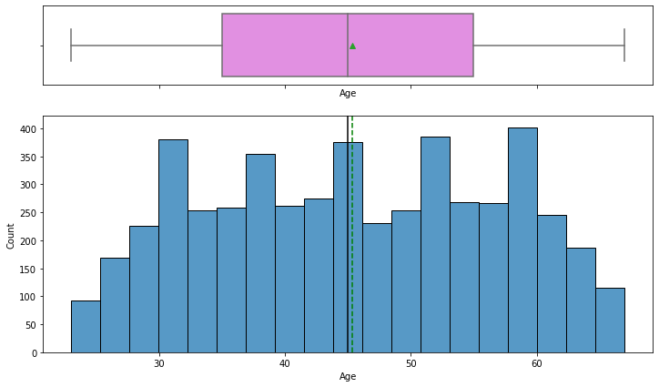

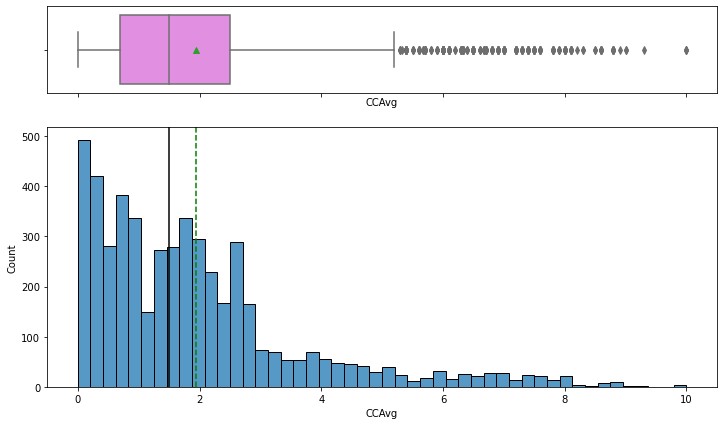

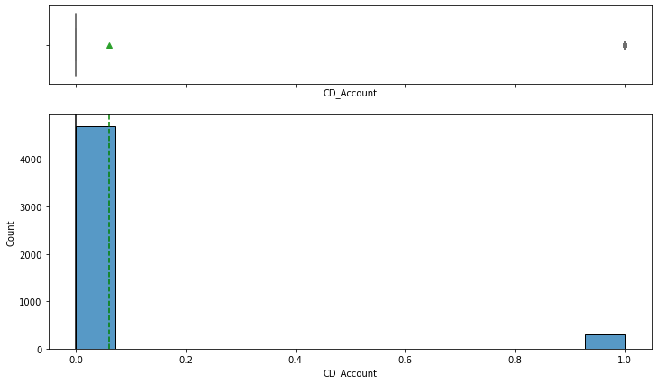

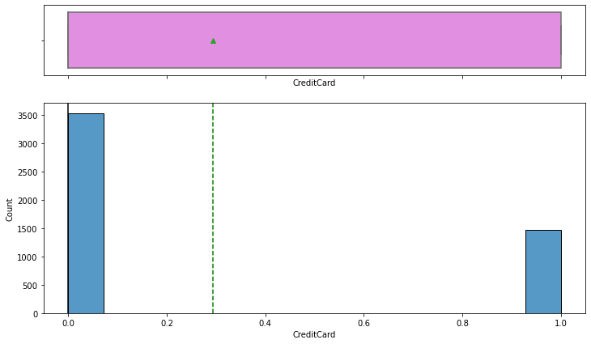

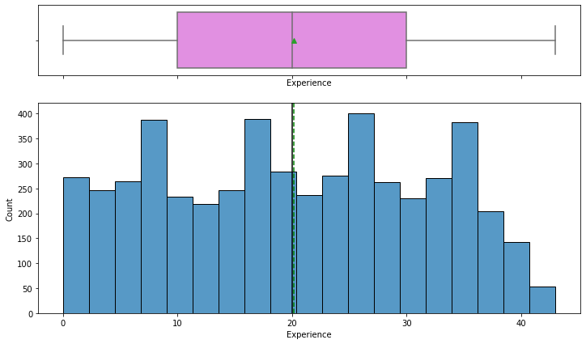

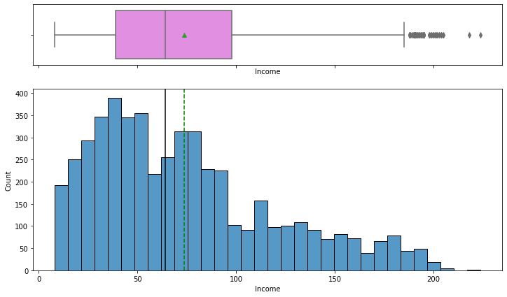

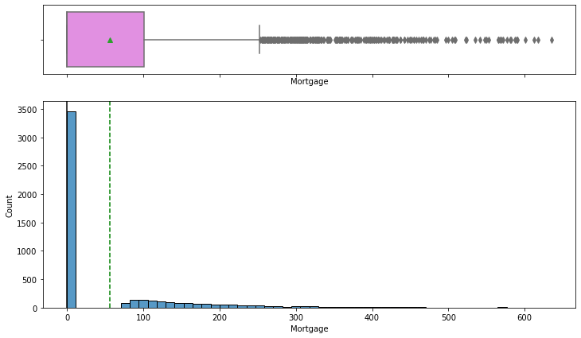

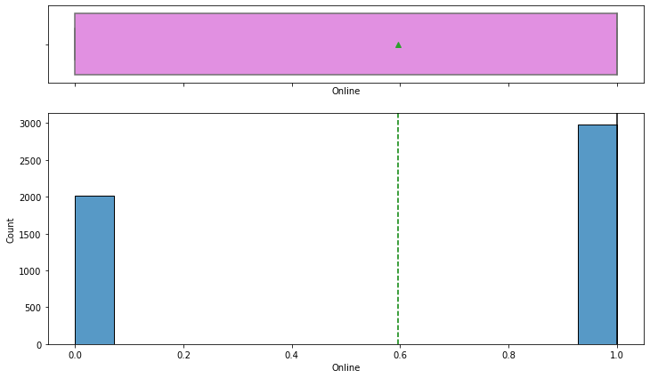

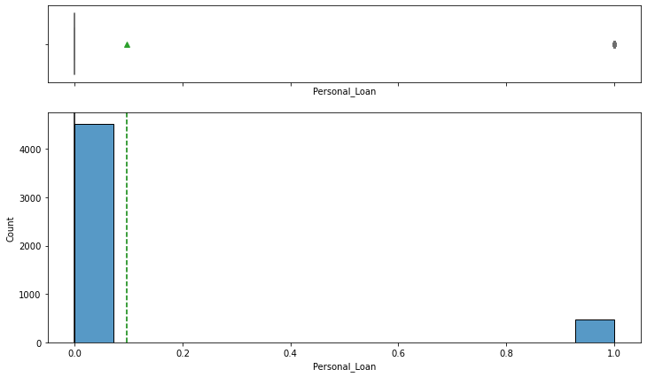

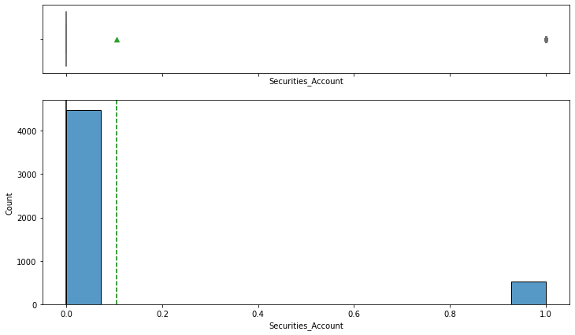

```python
#For every column in the dataframe that has a numerical datatype, show histogram and box plot
for colname in (data.columns[data.dtypes == 'int64'] | data.columns[data.dtypes == 'float64']):
    histogram_boxplot(data, colname)
```

Observation:

1. Age looks like it is normally distributed .
2. CCAvg is right skewed and also has many outliers
3. CD_Account is a boolean variable and we can see that most customers dont have a CD_Account.
4. CreditCard is also a boolean variable and we can see that most customers dont have a credit card.
5. Experience seems normally distributed.
6. Income is right skewed and has many outliers
7. Mortgage is skewed, where most customers dont have a mortgage but then there is a vast variety of mortgage amounts. It has many values as outliers.
8. Online is a boolean variable where most customers do use internet facilities.
9. Personal_Loan is our target variable and we can see that most customers have not taken a Personal_Loan. Only 480 customers have taken a personal loan. This makes this analysis more important so the study can identify potential customers that are a good fit to take personal loans.
10. Securities_Account is a boolean variable and shows that most customers do not have a Securities_Account

### Looking at non numerical variable analysis

```python
# function to create labeled barplots


def labeled_barplot(data, feature, perc=False, n=None):
    """
    Barplot with percentage at the top

    data: dataframe
    feature: dataframe column
    perc: whether to display percentages instead of count (default is False)
    n: displays the top n category levels (default is None, i.e., display all levels)
    """

    total = len(data[feature])  # length of the column
    count = data[feature].nunique()
    if n is None:
        plt.figure(figsize=(count + 1, 5))
    else:
        plt.figure(figsize=(n + 1, 5))

    plt.xticks(rotation=90, fontsize=15)
    ax = sns.countplot(
        data=data,
        x=feature,
        palette="Paired",
        order=data[feature].value_counts().index[:n].sort_values(),
    )

    for p in ax.patches:
        if perc == True:
            label = "{:.1f}%".format(
                100 * p.get_height() / total
            )  # percentage of each class of the category
        else:
            label = p.get_height()  # count of each level of the category

        x = p.get_x() + p.get_width() / 2  # width of the plot
        y = p.get_height()  # height of the plot

        ax.annotate(
            label,
            (x, y),
            ha="center",
            va="center",
            size=12,
            xytext=(0, 5),
            textcoords="offset points",
        )  # annotate the percentage

    plt.show()  # show the plot
```

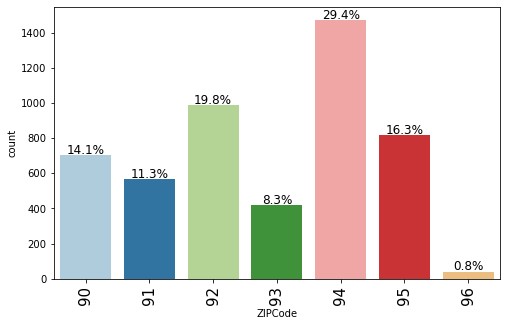

```
ZIPCode
```

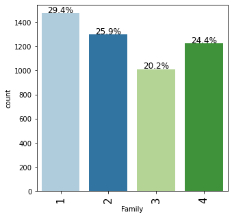

```
Family
```

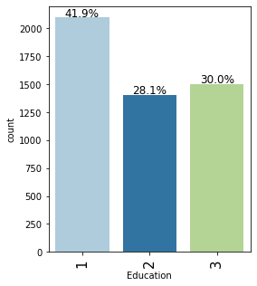

```
Education
```

```python
#For every column in the dataframe that has a categorical datatype, show distribution plot
for colname in data.columns[data.dtypes == 'category']:
    labeled_barplot(data, colname, perc=True)
    print(colname)
```

Observation: There are only 3 categorical variables.

1. The ZIPCode is used to group customers into 7 geographic regions using the first 2 characters of the zipcode. The most common geographic region among the customers is '94' with 29.4% of the population in this area. Next common region is 92 with 19.8 % of the customers in this region. This is followed by region '95' with 16.3% of the customers. Then its region '90' with 14.1 % of the customers. The least common region is '96' with only 0.8% of the customers in that region.
2. We can see that 29.4% of the customers have a family size of 1, indicating just individuals. Then there are 25.9% of customers who have a family size of 2 perhaps indicating couples. Then there are 24.4% of customers who have a fmaily size of 4. Finally only 20.2% have family size of 3.
3. 41.9% of customers have Education of 1 which indicates an Undergrad degree. 30% have Education of 3 indicating an Advanced or Professional degree. Lastly 28.1% have Education of 2 which indicates a Graduate degree.

### Outlier detection and treatment

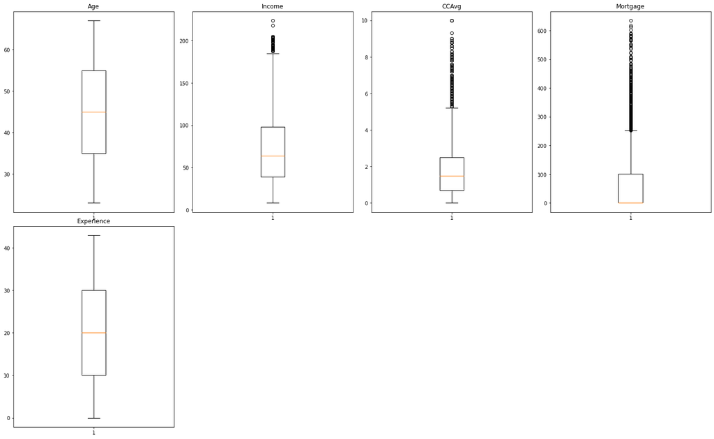

```python
#Outliers detection using box plot
#Listing the columns with continous numeric data, ignoring boolean columns
numerical_col = data[["Age","Income", "CCAvg", "Mortgage", "Experience", ]]
plt.figure(figsize=(20, 30))

for i, variable in enumerate(numerical_col):
    plt.subplot(5, 4, i + 1)
    plt.boxplot(data[variable], whis=1.5)
    plt.tight_layout()
    plt.title(variable)

plt.show()
```

Observation:

1. Age does not have any outliers.
2. Income has a few upper outliers
3. CCAvg has upper outliers
4. Mortgage has many upper outliers
5. Experience does not have any outliers

We can treat the outliers for Income, CCAvg and Mortgage by capping using the function below.

### Treating Outliers

```python
# functions to treat outliers by flooring and capping
def treat_outliers(df, col):
    """
    Treats outliers in a variable

    df: dataframe
    col: dataframe column
    """
    Q1 = df[col].quantile(0.25)  # 25th quantile
    Q3 = df[col].quantile(0.75)  # 75th quantile
    IQR = Q3 - Q1
    Lower_Whisker = Q1 - 1.5 * IQR
    Upper_Whisker = Q3 + 1.5 * IQR

    # all the values smaller than Lower_Whisker will be assigned the value of Lower_Whisker
    # all the values greater than Upper_Whisker will be assigned the value of Upper_Whisker
    df[col] = np.clip(df[col], Lower_Whisker, Upper_Whisker)

    return df
def treat_outliers_all(df, col_list):
    """
    Treat outliers in a list of variables

    df: dataframe
    col_list: list of dataframe columns
    """
    for c in col_list:
        df = treat_outliers(df, c)

    return df
```

```python
numerical_col = data[["Income", "CCAvg", "Mortgage"]]
data = treat_outliers_all(data, numerical_col)
```

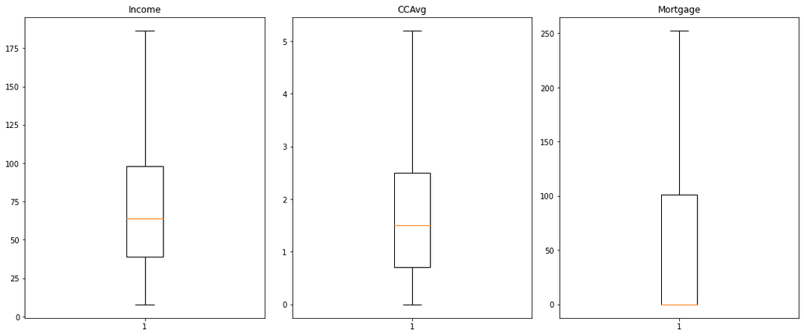

```python
# let's look at box plot to see if outliers have been treated or not
plt.figure(figsize=(20, 30))

for i, variable in enumerate(numerical_col):
    plt.subplot(5, 4, i + 1)
    plt.boxplot(data[variable], whis=1.5)
    plt.tight_layout()
    plt.title(variable)

plt.show()
```

Observation: We can see that the outliers have been treated for Income, CCAvg and Mortgage.

## Bivariate Analysis

### Looking at the relationship between numerical variables using pair plots and heat map

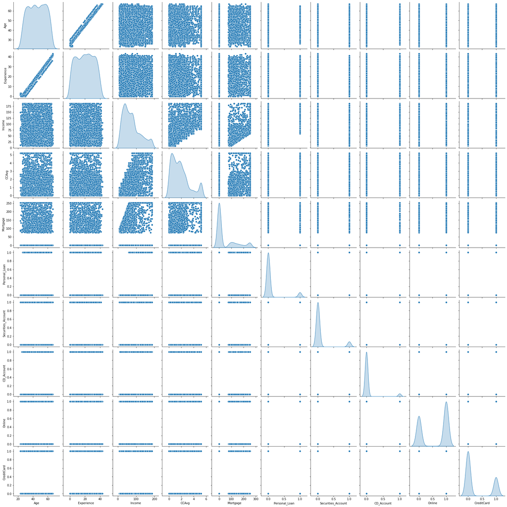

```python
sns.pairplot(data, diag_kind="kde")
```

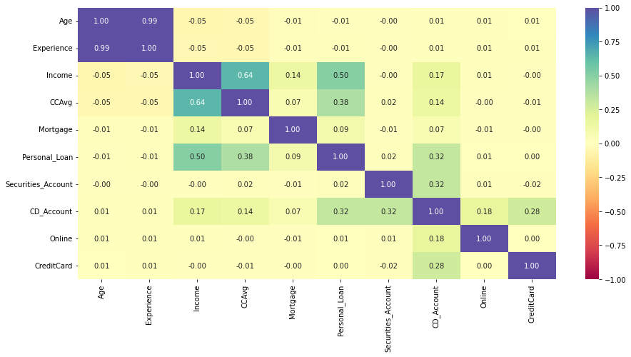

```python
correlation = data.corr()
plt.figure(figsize=(15, 7))
sns.heatmap(correlation, annot=True, vmin=-1, vmax=1, fmt=".2f", cmap="Spectral")
plt.show()
```

Observation: This bivariate analysis shows that Age and Experience are highly correlated. So we will drop Experience so we dont have highly corelated variables. Choosing to drop Experience instead of Age as Experience had data entry errors that we had to fix so this would be a good column to drop.

Also this shows that Personal_Loan is corelated to Income with 0.5 and then CCAvg with 0.38. This is followed lastly by CD_Account with 0.32.

```python
#Dropping highly corelated column Experience
data.drop(['Experience'],axis=1,inplace=True)
```

### Lets look at categorical columns with Personal_Loan

```python
def stacked_barplot(data, predictor, target):

    """
    Print the category counts and plot a stacked bar chart

    data: dataframe
    predictor: independent variable
    target: target variable
    """
    count = data[predictor].nunique()
    sorter = data[target].value_counts().index[-1]
    tab1 = pd.crosstab(data[predictor], data[target], margins=True).sort_values(
        by=sorter, ascending=False
    )
    print(tab1)
    print("-" * 120)
    tab = pd.crosstab(data[predictor], data[target], normalize="index").sort_values(
        by=sorter, ascending=False
    )
    tab.plot(kind="bar", stacked=True, figsize=(count + 5, 5))
    plt.legend(
        loc="lower left", frameon=False,
    )
    plt.legend(loc="upper left", bbox_to_anchor=(1, 1))
    plt.show()
```

```
Personal_Loan     0    1   All
ZIPCode
All            4520  480  5000
94             1334  138  1472
92              894   94   988
95              735   80   815
90              636   67   703
91              510   55   565
93              374   43   417
96               37    3    40
------------------------------------------------------------------------------------------------------------------------
```

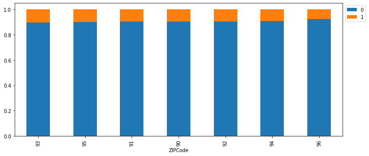

```
Personal_Loan     0    1   All
Family
All            4520  480  5000
4              1088  134  1222
3               877  133  1010
1              1365  107  1472
2              1190  106  1296
------------------------------------------------------------------------------------------------------------------------
```

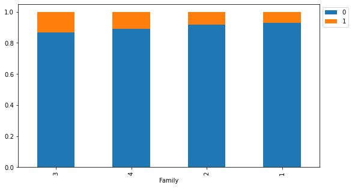

```
Personal_Loan     0    1   All
Education
All            4520  480  5000
3              1296  205  1501
2              1221  182  1403
1              2003   93  2096
------------------------------------------------------------------------------------------------------------------------
```

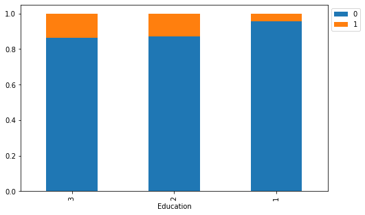

```python
#For every category column print a countplot with category and price to see how they are related.
for colname in (data.columns[data.dtypes == 'category']):
    stacked_barplot(data, colname, 'Personal_Loan')
```

Observation:

Most of the customers are in ZIPCode that starts with '94' , then '92', '95', '90', '91', and '93'. The least customers are in '96'. The customers in '94' ZIPCode had the most Personal_loan with 138 customers, then ZIPCode '92' with 94 customers who took a Personal_Loan.

The most common family size is 1, indicating single individuals, Then its family size of 2, followed by 4 and lastly family size 3 is the least common. Customers with family size of 4 and 3 have the most customers who took a Personal_Loan. Customers with family size of 1 and 2 did not have as many customers who took a Personal_Loan.

The most common Education is 1 indicating an Undergraduate degree. Then its 3 indicating an Advanced degree and finally 2 which is a Grduate degree. Customers with an Advanced degree took more loans, then cutomers who had a Graduate degree. Customers with an Undergraduate degree had the least number of customers who took Personal loans.

### Summary of EDA and Data cleansing

1. There are 5000 rows and 14 columns
2. There are no duplicates
3. There were no null values
4. We dropped the ID column as it was a customer identifier and not useful for data analysis
5. Converted ZIPCode to string and used the first 2 characters to come up with 7 geographic groups. Updated column to category
6. Changed the data type of Family to categorical
7. Changed the data type of Education to categorical
8. Fixed the data entry errors in Experience where it had -1, -2 and -3 values. Updated them to the absolute values. However, we dropped this column as it was highly correlated with Age. We chose to drop this column instead of Age as Experience had data entry issues.

### Summary of univariate Analysis

1. Age looks like it is normally distributed
2. CCAvg is right skewed and also has many upper outliers. This was treated using capping.
3. CD_Account is a boolean variable and we can see that most customers dont have a CD_Account.
4. CreditCard is also a boolean variable and we can see that most customers dont have a credit card.
5. Income is right skewed and has many upper outliers. The outliers were treated using capping.
6. Mortgage is skewed, where most customers dont have a mortgage but then there is a vast variety of mortgage amounts. It has many values as upper outliers.The outliers were treated using capping.
7. Online is a boolean variable where most customers do use internet facilities.
8. Securities_Account is a boolean variable and shows that most customers do not have a Securities_Account
9. Personal_Loan is our target variable and we can see that most customers have not taken a Personal_Loan. From 5000 customers, only 480 customers have taken a personal loan. This makes this analysis more important so the study can identify potential customers that are a good fit to take personal loans.
10. The ZIPCode is used to group customers into 7 geographic regions using the first 2 characters of the zipcode. The most common geographic region among the customers is '94' with 29.4% of the population in this area. Next common region is 92 with 19.8 % of the customers in this region. This is followed by region '95' with 16.3% of the customers. Then its region '90' with 14.1 % of the customers. The least common region is '96' with only 0.8% of the customers in that region.
11. We can see that 29.4% of the customers have a family size of 1, indicating just individuals. Then there are 25.9% of customers who have a family size of 2 perhaps indicating couples. Then there are 24.4% of customers who have a fmaily size of 4. Finally only 20.2% have family size of 3.
12. 41.9% of customers have Education of 1 which indicates an Undergrad degree. 30% have Education of 3 indicating an Advanced or Professional degree. Lastly 28.1% have Education of 2 which indicates a Graduate degree.

### Summary of bivariate Analysis

1. Personal_Loan is corelated to Income with 0.5 and then CCAvg with 0.38. This is followed lastly by CD_Account with 0.32.
2. Most of the customers are in ZIPCode that starts with '94' , then '92', '95', '90', '91', and '93'. The least customers are in '96'. The customers in '94' ZIPCode had the most Personal_loan with 138 customers, then ZIPCode '92' with 94 customers who took a Personal_Loan.
3. The most common family size is 1, indicating single individuals, Then its family size of 2, followed by 4 and lastly family size 3 is the least common. Customers with family size of 4 and 3 have the most customers who took a Personal_Loan. Customers with family size of 1 and 2 did not have as many customers who took a Personal_Loan.
4. The most common Education is 1 indicating an Undergraduate degree. Then its 3 indicating an Advanced degree and finally 2 which is a Grduate degree. Customers with an Advanced degree took more loans, then cutomers who had a Graduate degree. Customers with an Undergraduate degree had the least number of customers who took Personal loans.